# CaseStudy1.md

Cameron

April 29, 2018

# Case Study #1

An exploration of the quality of different visualizations

## Visualization #1:

[figure not shown]

### Purpose

[source](https://www.washingtonpost.com/news/wonk/wp/2018/04/30/these-are-the-industries-trump-should-protect-from-china-if-he-wants-to-win-elections/?utm_term=.4d99ad2fe78b)

This graph comes from a Washington Post article explaining the effects of Trump’s Tarriffs on swing voter states.

### Pros

First of all, there is a sorted order to all of the industries. The one’s with the most presense in swing states are at top and the order descends from there. This makes it very readable. Second, I like that they are using the circles to also weigh in the employment count for each industry. I feel that this variable is just as important, if not more important, than the percentage of the industry that is concetrated in each swing state. Third of all, I feel as though the descriptions do a good job of explaining but not over-explaining the role of each piece of information in the chart. I felt the descriptions were very useful. Finally, I think comparing these percentages to the national average was a useful metric to give an idea of how most industries are represented in swing states.

## Visualization #2:

### Purpose

[source](https://www.washingtonpost.com/news/wonk/wp/2018/04/30/these-are-the-industries-trump-should-protect-from-china-if-he-wants-to-win-elections/?utm_term=.4d99ad2fe78b)

## Some R code

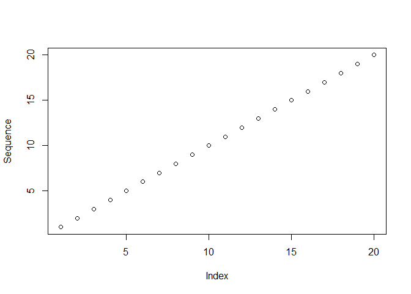

Without looking at the markdown file, I’m going to guess that this is going to create a plot (maybe a scatterplot) of the sequence of numbers from 1 to 20. I will see if I was right……

I think I was pretty accurate.